# Hacker News Analysis

2021-01-18

# Analysis of Required Sampling Rate

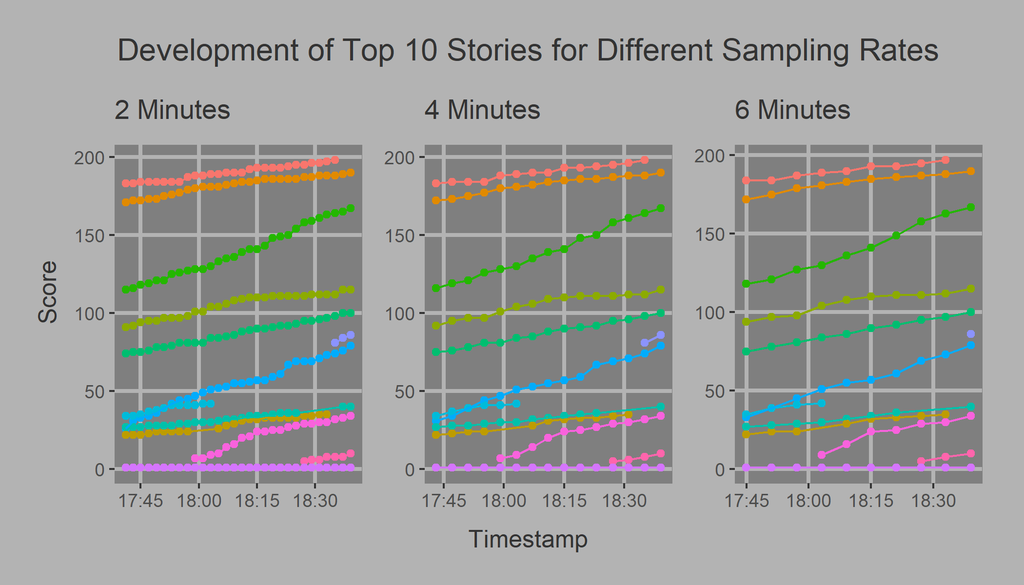

# What Happens on the `new` Page?

Presumably, the `new` page on Hacker News is the only way for newly created stories to gain traction. Hence, it is important to have a look at how large this window of opportunity is.

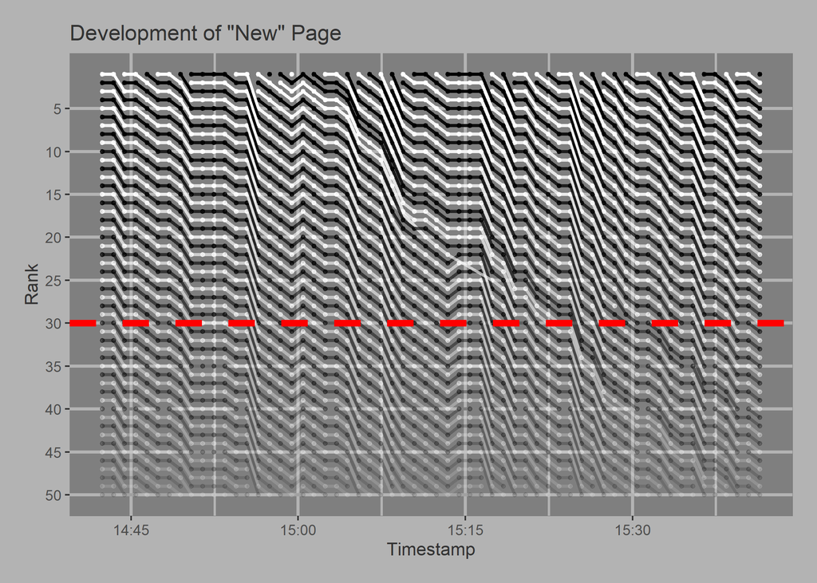

# The `top stories` Page

There are 721 stories by 554 different users in the data set. The data set covers a range of 21.97 in intervals of two minutes.

Even though all topstories cannot be scraped at exactly the same time, there are only minor time delays in the scraping process, with a mean of 4.64 seconds, a median of 4.26 seconds, and a standard deviation of 0.71 seconds. The maximum delay was 8.76 seconds which is in an acceptable range.

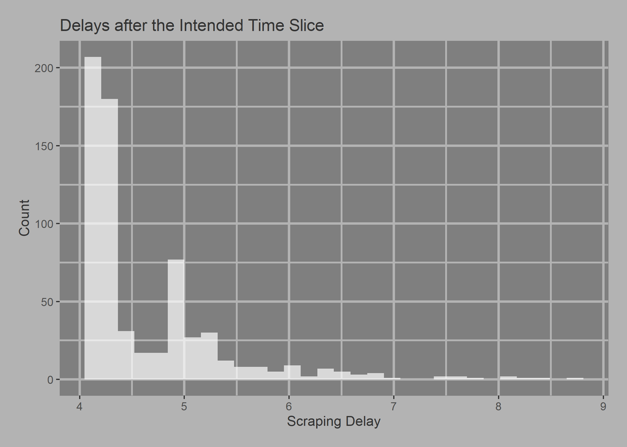

Scores and comment counts seem to be exponentially distributed as could be expected. Note that posts with more than 500 comments were excluded in the lower plot because of some extreme outliers that would have made the visual analysis of the remaining data difficult.

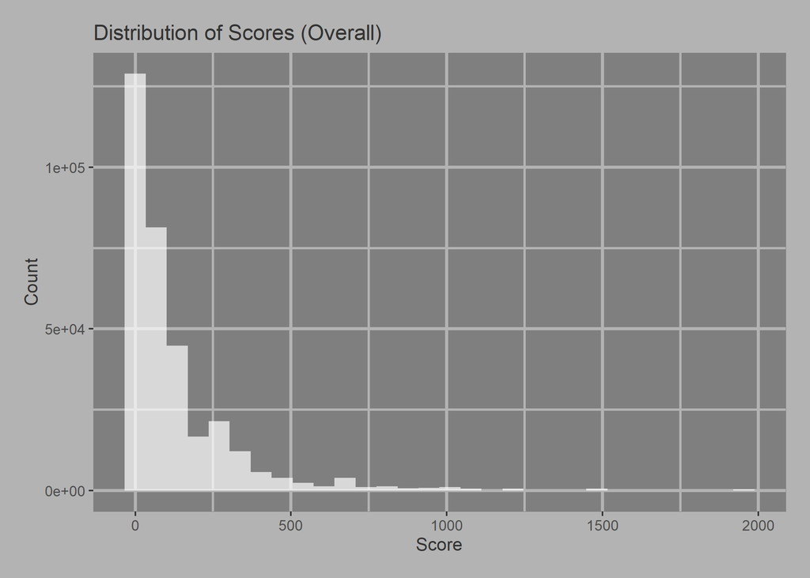

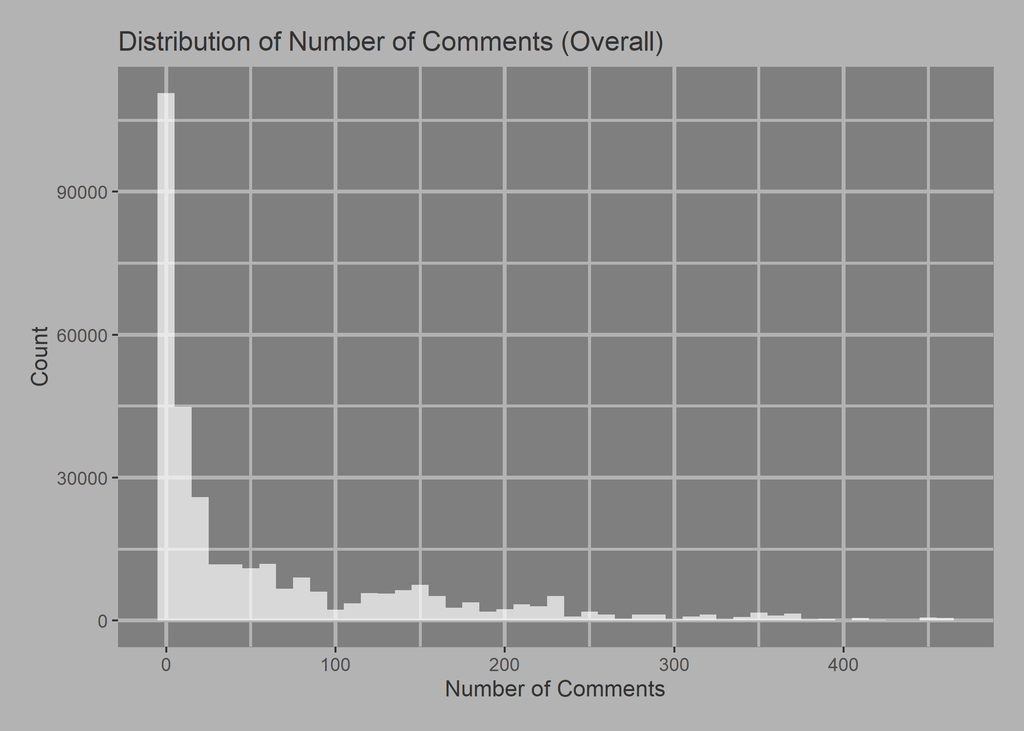

## How Do Stories Develop that have at Some Point Reached Rank 1?

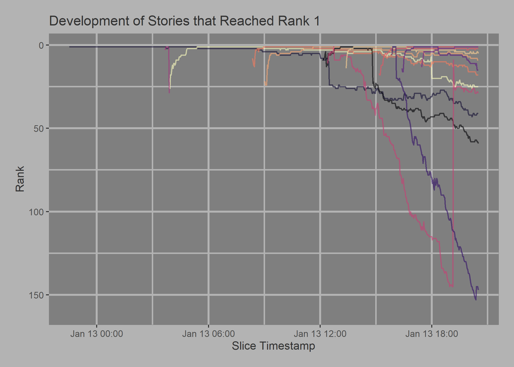

# Remaining Questions

- Maximum age for top stories?
- All new stories in top stories?
- Minimum number of votes to make the top list

Longterm:

- Stackoverflow